# Part3

```r
set.seed(42)
```

### Question (a)

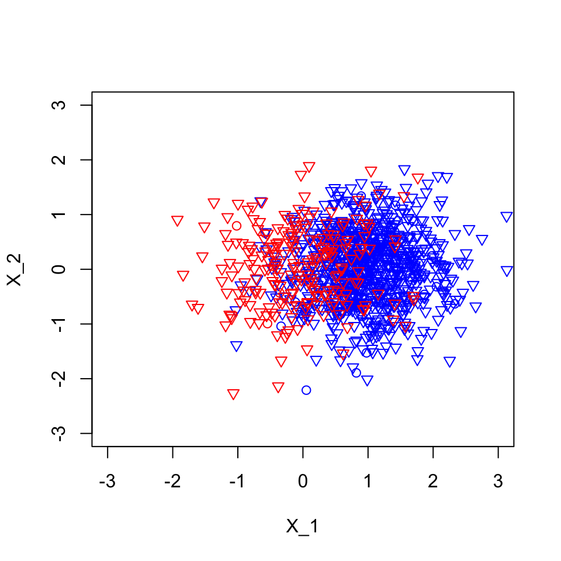

```r
library(MASS)

generate_dataset <- function(N, eps, p)
{
  mu_0 = c(0, 0)
  sg_0 = matrix(c(0.5,0,0,0.5),2,2)
  mu_1 = c(eps, 0)
  sg_1 = matrix(c(0.4,0,0,0.4),2,2)
  Y = c()
  X = matrix(0, N, 2)
  B = runif(N)
  for (i in 1:N)
  {
    Bi = runif(1)
    if(Bi < p)
    {
      Yi = 1
      Xi = mvrnorm(n=1, mu=mu_0, Sigma=sg_0)
    }
    else
    {
      Yi = 0
      Xi = mvrnorm(n=1, mu=mu_1, Sigma=sg_1)
    }
    Y = c(Y, Yi)
    X[i,] = Xi
  }
  newList <- list("X" = X, "y" = Y)
}

N_train = 50
N_test = 1000
eps = 1
p = 0.2
D_train = generate_dataset(N=N_train, eps, p)
D_test = generate_dataset(N=N_test, eps, p)

X_train = D_train$X
y_train = D_train$y
X_test = D_test$X
y_test = D_test$y

X = rbind(X_train, X_test)
y = rbind(y_train, y_test)

plot(X[,1], X[,2], col='white', xlab='X_1', ylab='X_2', xlim=c(-3, +3), ylim=c(-3, +3))

points(X_train[y_train==0,1], X_train[y_train==0,2], col='blue', pch=1)
points(X_train[y_train==1,1], X_train[y_train==1,2], col='red', pch=1)
points(X_test[y_test==0,1], X_test[y_test==0,2], col='blue', pch=6)
points(X_test[y_test==1,1], X_test[y_test==1,2], col='red', pch=6)
```

### Question (b)

We know that the ratio of the probabilities in terms of $\mathbf{x} = (x_1, x_2)$ is
$$R(x_1, x_2) = \dfrac{\text{Prob}(Y = 1 \mid \mathbf{x})}{\text{Prob}(Y
= 0 \mid \mathbf{x})} = \dfrac{\mathcal{N}(\boldsymbol{\mu}_1,
\boldsymbol{\Sigma}_1) \times p}{\mathcal{N}(\boldsymbol{\mu}_0,
\boldsymbol{\Sigma}_0) \times (1-p)}$$
with
$$\mathcal{N}(\boldsymbol{\mu}_1, \boldsymbol{\Sigma}_1) = \dfrac{1}{\pi}
\times \exp\Big(-\mathbf{x}^\top\mathbf{x} \Big) = \dfrac{1}{\pi} \times
\exp\Big(-(x_1^2 + x_2^2) \Big)$$
and
$$\mathcal{N}(\boldsymbol{\mu}_0, \boldsymbol{\Sigma}_0) =
\dfrac{1.25}{\pi} \times \exp\left(-1.25\Big((x_1 - \varepsilon)^2 +
x_2^2\Big)\right)$$
so that we can simplify to get
$$R(x_1, x_2) = \dfrac{\text{Prob}(Y = 1 \mid \mathbf{x})}{\text{Prob}(Y
= 0 \mid \mathbf{x})} = \dfrac{1}{1.25} \times \exp\left(1.25\Big((x_1 -
\varepsilon)^2 + x_2^2\Big) -(x_1^2 + x_2^2)\right) \times
\dfrac{p}{(1-p)}$$
and going further we get
$$R(x_1, x_2) = \dfrac{\text{Prob}(Y = 1 \mid \mathbf{x})}{\text{Prob}(Y =
0 \mid \mathbf{x})} = \exp\Big(0.25~x_1^2 - 2.5~x_1\varepsilon +
1.25~\varepsilon^2 \Big) \times \dfrac{0.8~p}{(1-p)}$$

The Bayes classifier is given by
$$h(\mathbf{x}) = h(x_1, x_2) = \mathbf{1}_{\{R(x_1, x_2) > 1\}}$$
and the boundary is defined by the points in which $R(x_1, x_2) = 1$ so we have
$$\exp\Big(0.25~x_1^2 - 2.5~x_1\varepsilon + 1.25~\varepsilon^2 \Big)
\times \dfrac{0.8~p}{(1-p)} = 1$$
which is the same as saying they are the points $(x_1, x_2)$ for which
$$\dfrac{1}{4}x_1^2 - \dfrac{5\varepsilon}{2}x_1 +
\dfrac{5}{4}\varepsilon^2 = \log\left(\dfrac{(1-p)}{0.8p}\right)$$

### Question (c)

```r
bayes_classifier <- function(x, eps, p)
{
  x1 = x[1]
  R = exp(0.25*x1^2 - 2.5*x1*eps + 1.25*eps^2) * 0.8*p/(1-p)
  if(R > 1)
  {
    return(1)
  }
  else{
    return(0)
  }
}

acc = c()
for (i in 1:N_test)
{
  Y_pred = bayes_classifier(D_test$X[i,], eps, p)
  Y_true = D_test$y[i]
  acc = c(acc, Y_pred == Y_true)
}
acc = sum(acc) / N_test
sprintf("score with Bayes classifier: %.2f", acc)
```

```
## [1] "score with Bayes classifier: 0.86"
```

The parameter $\varepsilon$ indicates how far the two classes are and, therefore, it determines how difficult is the problem of classifying the data points. With larger $\varepsilon$ the classes are more distant from each other and the classification scores have the tendency to increase.

### Question (d)

The class conditional pdfs are Gaussian and each one has a different covariance. Therefore, QDA seems like a good choice. Note, however, that since the covariance matrices are diagonal, the coordinates are independent, so the most natural choice is in fact the Gaussian naive Bayes classifier.

### Question (e)

```r
library(MASS)
df_train = data.frame(y_train, X_train)
clf_lda = lda(y_train ~ ., data=df_train)
df_test = data.frame(X_test)
pred = predict(clf_lda, newdata=df_test)
y_pred = pred$class
acc = sum(y_pred == y_test) / N_test
sprintf("score with LDA: %.2f", acc)
```

```
## [1] "score with LDA: 0.82"
```

```r
df_train = data.frame(y_train, X_train)
clf_qda = qda(y_train ~ ., data=df_train)
df_test = data.frame(X_test)
pred = predict(clf_qda, newdata=df_test)
y_pred = pred$class
acc = sum(y_pred == y_test) / N_test
sprintf("score with QDA: %.2f", acc)
```

```
## [1] "score with QDA: 0.83"
```

```r
df_train = data.frame(y_train, X_train)
clf_lgr = glm(y_train ~ ., family=binomial, data=df_train)
df_test = data.frame(X_test)
probabilities = predict(clf_lgr, newdata=df_test, type="response")
y_pred <- ifelse(probabilities > 0.5, 1, 0)
acc = sum(y_pred == y_test) / N_test
sprintf("score with Logistic Regression: %.2f", acc)
```

```
## [1] "score with Logistic Regression: 0.81"
```

The scores with LDA, QDA, and logistic regression are slightly inferior to the score with the Bayes classifier.

### Question (f)

```r
p = 0.8
D_test_prime = generate_dataset(N=N_test, eps, p)
X_test_prime = D_test_prime$X
y_test_prime = D_test_prime$y
df_test_prime = data.frame(X_test_prime)

pred = predict(clf_lda, newdata=df_test_prime)
y_pred = pred$class
acc = sum(y_pred == y_test_prime) / N_test
sprintf("score with LDA: %.2f", acc)
```

```
## [1] "score with LDA: 0.65"
```

```r
pred = predict(clf_qda, newdata=df_test_prime)
y_pred = pred$class
acc = sum(y_pred == y_test_prime) / N_test
sprintf("score with QDA: %.2f", acc)
```

```
## [1] "score with QDA: 0.64"
```

```r
probabilities = predict(clf_lgr, newdata=df_test_prime, type="response")
y_pred <- ifelse(probabilities > 0.5, 1, 0)
acc = sum(y_pred == y_test_prime) / N_test
sprintf("score with Logistic Regression: %.2f", acc)
```

```
## [1] "score with Logistic Regression: 0.66"
```

The scores have decreases for all three classifiers. This is not surprising, since the statistics of the data points in the test set are **different** from those in the training dataset. This is a typical setting of transfer learning.